# group project 2

Group 05

2022/3/15

```r
film <- read.csv("dataset5.csv")
```

# 1 Introduction of dataset

## 1.1 question of dataset

Imagine you have been asked by a film producer to investigate the following question of interest:

- Which properties of films influence whether they are rated by IMDB as greater than 7 or not?

You should conduct an analysis to answer your question using a Generalised Linear Model (GLM).  
Following your analyses, you should then summarise your results in the form of a presentation.

## 1.2 explain each variables

- film.id – The unique identifier for the film
- year – Year of release of the film in cinemas
- length – Duration (in minutes)
- budget – Budget for the films production (in $1000000s)
- votes – Number of positive votes received by viewers
- genre – Genre of the film
- rating – IMDB rating from 0-10

# 2 data processing

create a col seperate the rate: >7(1), <=7(0)

```r
film <- film %>%
  mutate(rating.large7 = cut(rating, breaks = c(0,7,Inf), labels=c(0,1))) %>%
  dplyr::select(-film_id, -rating)%>%
  na.omit()
```

# 3 Exploratory data analysis

## 3.1 the distribution of rating.large7 by genre

```r
film %>%
  group_by(genre, rating.large7)%>%
  summarise(n = n())
```

| genre | rating.large7 | n |
| --- | --- | --- |
| Action | 0 | 563 |
| Action | 1 | 117 |
| Animation | 0 | 49 |
| Animation | 1 | 111 |
| Comedy | 0 | 224 |
| Comedy | 1 | 325 |
| Documentary | 0 | 11 |
| Documentary | 1 | 121 |
| Drama | 0 | 620 |
| Drama | 1 | 34 |

[output cut: 3 more lines]

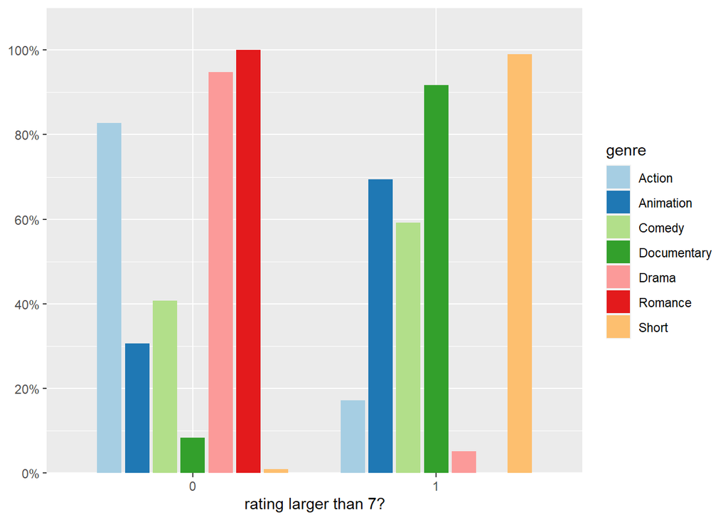

```r
plot_xtab(film$rating.large7,film$genre,show.values =FALSE,show.total =FALSE,
axis.labels =c("0","1"),
axis.titles=c("rating larger than 7?"))
```

## 3.2 the distribution of rating.large7 by other numerical variables

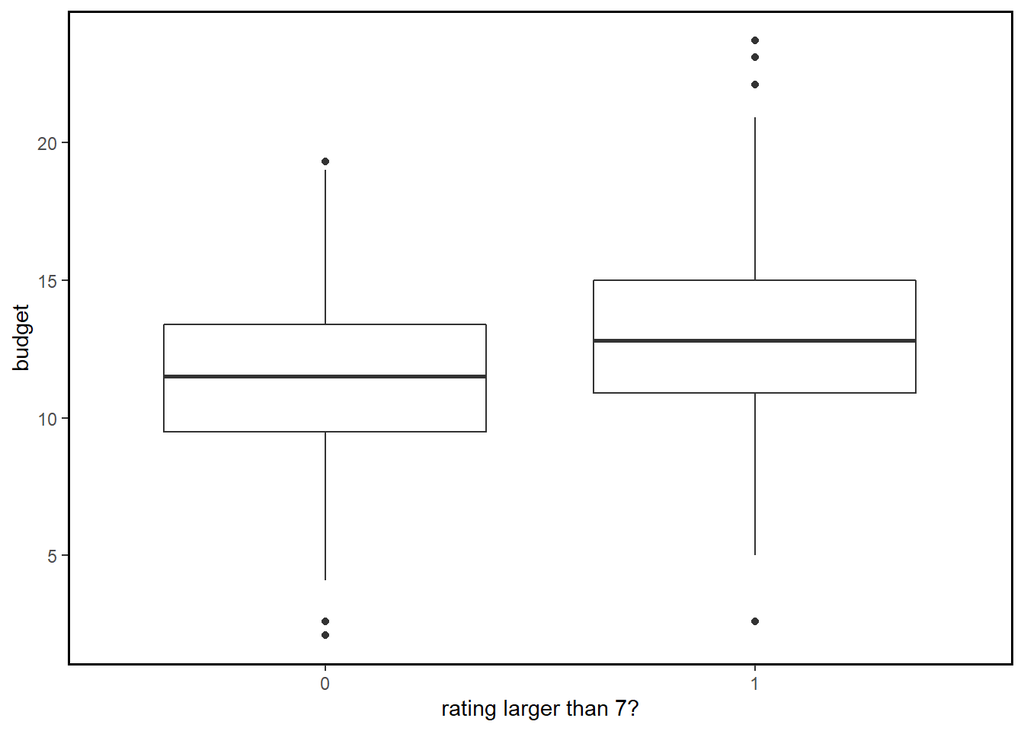

```r
## budget
film.plot1<-ggplot(film, aes(y=budget,x=rating.large7))

film.plot1+geom_boxplot()+xlab("rating larger than 7?")+
theme(panel.background =element_rect(fill ="transparent",colour =NA),
plot.background =element_rect(fill ="transparent",colour =NA),
panel.border =element_rect(fill =NA,colour ="black",size =1))
```

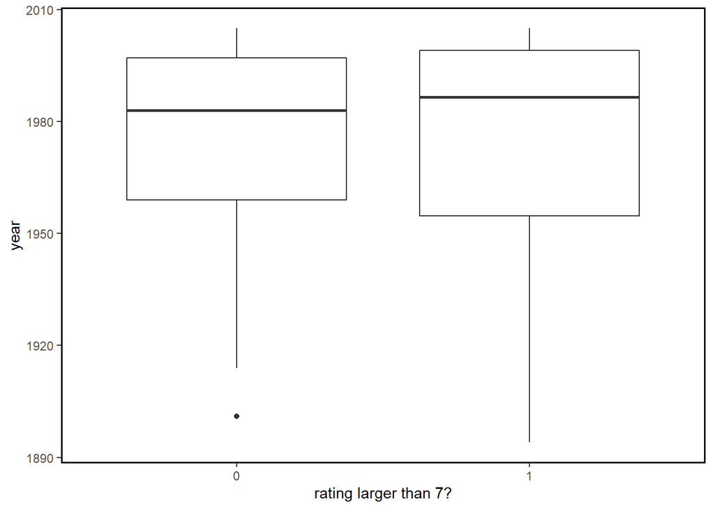

```r
## year
film.plot2<-ggplot(film, aes(y=year,x=rating.large7))

film.plot2+geom_boxplot()+xlab("rating larger than 7?")+
theme(panel.background =element_rect(fill ="transparent",colour =NA),
plot.background =element_rect(fill ="transparent",colour =NA),
panel.border =element_rect(fill =NA,colour ="black",size =1))
```

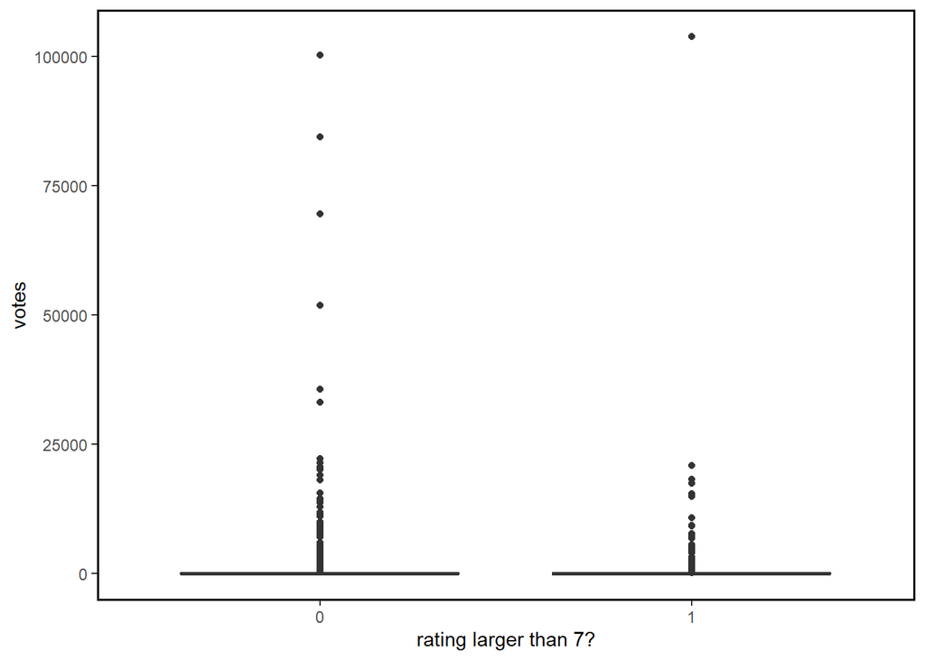

```r
## votes
film.plot3<-ggplot(film, aes(y=votes,x=rating.large7))

film.plot3+geom_boxplot()+xlab("rating larger than 7?")+
theme(panel.background =element_rect(fill ="transparent",colour =NA),
plot.background =element_rect(fill ="transparent",colour =NA),
panel.border =element_rect(fill =NA,colour ="black",size =1))
```

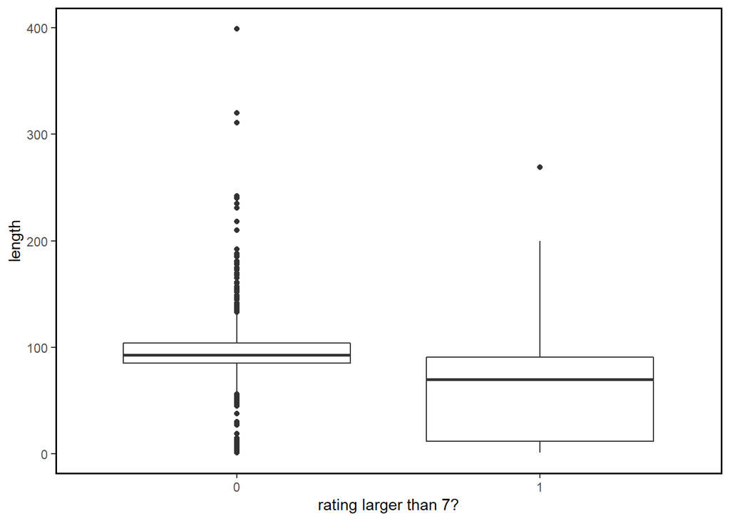

```r
## length
film.plot4<-ggplot(film, aes(y=length,x=rating.large7))

film.plot4+geom_boxplot()+xlab("rating larger than 7?")+
theme(panel.background =element_rect(fill ="transparent",colour =NA),
plot.background =element_rect(fill ="transparent",colour =NA),
panel.border =element_rect(fill =NA,colour ="black",size =1))
```

# 4 formal analysis

## 4.1 stepwise: choosing which variables need to be removed.

Since Model2(removed year) has lowest AIC=1310.1 and deviance D=1290.1 we will go ahead and compared the three link function in our model

```r
model <-  glm(rating.large7 ~ year + length + budget + votes + genre, family = binomial(link = "logit"), data = film)

logit.step <- step(model,direction='both')
```

```
## Start:  AIC=1311.03
## rating.large7 ~ year + length + budget + votes + genre
##
##          Df Deviance    AIC
## - year    1   1290.1 1310.1
## <none>        1289.0 1311.0
## - votes   1   1293.0 1313.0
## - length  1   1599.9 1619.9
## - budget  1   1663.1 1683.1
## - genre   6   2110.1 2120.1
##
## Step:  AIC=1310.07
## rating.large7 ~ length + budget + votes + genre
##
##          Df Deviance    AIC
## <none>        1290.1 1310.1
## + year    1   1289.0 1311.0
## - votes   1   1294.3 1312.3
## - length  1   1609.3 1627.3
## - budget  1   1664.8 1682.8
## - genre   6   2130.3 2138.3
```

```r
summary(logit.step)
```

```
##
## Call:
## glm(formula = rating.large7 ~ length + budget + votes + genre,
##     family = binomial(link = "logit"), data = film)
##
## Deviance Residuals:
##     Min       1Q   Median       3Q      Max
## -3.7603  -0.4107  -0.1148   0.2614   4.1785
##
## Coefficients:
##                    Estimate Std. Error z value Pr(>|z|)
## (Intercept)      -3.618e+00  4.428e-01  -8.170 3.09e-16 ***
## length           -5.129e-02  3.566e-03 -14.382  < 2e-16 ***
## budget            4.962e-01  3.147e-02  15.770  < 2e-16 ***
## votes             3.609e-05  1.672e-05   2.159   0.0309 *
## genreAnimation   -1.974e-01  3.378e-01  -0.584   0.5590
## genreComedy       2.749e+00  1.835e-01  14.983  < 2e-16 ***
## genreDocumentary  4.840e+00  4.098e-01  11.809  < 2e-16 ***
## genreDrama       -2.040e+00  2.580e-01  -7.907 2.64e-15 ***
## genreRomance     -1.361e+01  3.138e+02  -0.043   0.9654
## genreShort        4.209e+00  1.050e+00   4.008 6.12e-05 ***
## ---
## Signif. codes:  0 '***' 0.001 '**' 0.01 '*' 0.05 '.' 0.1 ' ' 1
##
## (Dispersion parameter for binomial family taken to be 1)
##
##     Null deviance: 2982.5  on 2294  degrees of freedom
## Residual deviance: 1290.1  on 2285  degrees of freedom
## AIC: 1310.1
##
## Number of Fisher Scoring iterations: 14
```

## 4.2 compare different link functions

the AIC and BIC in model1 is the smallest, and the Pseudo-R² is the largest. Hence we choose ‘logit’ link function to fit our model

### 4.2.1 Model 1: logit link

```r
model1 <- glm(rating.large7 ~ length + budget + votes + genre, family = binomial(link = "logit"), data = film)
summary(model1)
```

```
##
## Call:
## glm(formula = rating.large7 ~ length + budget + votes + genre,
##     family = binomial(link = "logit"), data = film)
##
## Deviance Residuals:
##     Min       1Q   Median       3Q      Max
## -3.7603  -0.4107  -0.1148   0.2614   4.1785
##
## Coefficients:
##                    Estimate Std. Error z value Pr(>|z|)
## (Intercept)      -3.618e+00  4.428e-01  -8.170 3.09e-16 ***
## length           -5.129e-02  3.566e-03 -14.382  < 2e-16 ***
## budget            4.962e-01  3.147e-02  15.770  < 2e-16 ***
## votes             3.609e-05  1.672e-05   2.159   0.0309 *
## genreAnimation   -1.974e-01  3.378e-01  -0.584   0.5590
## genreComedy       2.749e+00  1.835e-01  14.983  < 2e-16 ***
## genreDocumentary  4.840e+00  4.098e-01  11.809  < 2e-16 ***
## genreDrama       -2.040e+00  2.580e-01  -7.907 2.64e-15 ***
## genreRomance     -1.361e+01  3.138e+02  -0.043   0.9654
## genreShort        4.209e+00  1.050e+00   4.008 6.12e-05 ***
## ---
## Signif. codes:  0 '***' 0.001 '**' 0.01 '*' 0.05 '.' 0.1 ' ' 1
##
## (Dispersion parameter for binomial family taken to be 1)
##
##     Null deviance: 2982.5  on 2294  degrees of freedom
## Residual deviance: 1290.1  on 2285  degrees of freedom
## AIC: 1310.1
##
## Number of Fisher Scoring iterations: 14
```

```r
summ(model1)
```

| Observations | 2295 |
| --- | --- |
| Dependent variable | rating.large7 |
| Type | Generalized linear model |
| Family | binomial |
| Link | logit |

| χ2(9) | 1692.40 |
| --- | --- |
| Pseudo-R2 (Cragg-Uhler) | 0.72 |
| Pseudo-R2 (McFadden) | 0.57 |
| AIC | 1310.07 |
| BIC | 1367.45 |

|  | Est. | S.E. | z val. | p |
| --- | --- | --- | --- | --- |
| (Intercept) | -3.62 | 0.44 | -8.17 | 0.00 |
| length | -0.05 | 0.00 | -14.38 | 0.00 |
| budget | 0.50 | 0.03 | 15.77 | 0.00 |
| votes | 0.00 | 0.00 | 2.16 | 0.03 |
| genreAnimation | -0.20 | 0.34 | -0.58 | 0.56 |
| genreComedy | 2.75 | 0.18 | 14.98 | 0.00 |
| genreDocumentary | 4.84 | 0.41 | 11.81 | 0.00 |
| genreDrama | -2.04 | 0.26 | -7.91 | 0.00 |
| genreRomance | -13.61 | 313.77 | -0.04 | 0.97 |
| genreShort | 4.21 | 1.05 | 4.01 | 0.00 |

Standard errors: MLE

### 4.2.2 Model 2: probit link

```r
model2 <- glm(rating.large7 ~ length + budget + votes + genre, family = binomial(link = "probit"), data = film)
summary(model2)
```

```
##
## Call:
## glm(formula = rating.large7 ~ length + budget + votes + genre,
##     family = binomial(link = "probit"), data = film)
##
## Deviance Residuals:
##     Min       1Q   Median       3Q      Max
## -4.1883  -0.4440  -0.0870   0.2847   4.8941
##
## Coefficients:
##                    Estimate Std. Error z value Pr(>|z|)
## (Intercept)      -2.083e+00  2.342e-01  -8.895  < 2e-16 ***
## length           -2.565e-02  1.792e-03 -14.312  < 2e-16 ***
## budget            2.637e-01  1.604e-02  16.442  < 2e-16 ***
## votes             1.937e-05  8.570e-06   2.261   0.0238 *
## genreAnimation    6.224e-02  1.818e-01   0.342   0.7321
## genreComedy       1.468e+00  9.656e-02  15.202  < 2e-16 ***
## genreDocumentary  2.639e+00  2.074e-01  12.720  < 2e-16 ***
## genreDrama       -1.117e+00  1.319e-01  -8.468  < 2e-16 ***
## genreRomance     -4.742e+00  7.702e+01  -0.062   0.9509
## genreShort        2.307e+00  4.497e-01   5.131 2.88e-07 ***
## ---
## Signif. codes:  0 '***' 0.001 '**' 0.01 '*' 0.05 '.' 0.1 ' ' 1
##
## (Dispersion parameter for binomial family taken to be 1)
##
##     Null deviance: 2982.5  on 2294  degrees of freedom
## Residual deviance: 1314.7  on 2285  degrees of freedom
## AIC: 1334.7
##
## Number of Fisher Scoring iterations: 14
```

```r
summ(model2)
```

| Observations | 2295 |
| --- | --- |
| Dependent variable | rating.large7 |
| Type | Generalized linear model |
| Family | binomial |
| Link | probit |

| χ2(9) | 1667.81 |
| --- | --- |
| Pseudo-R2 (Cragg-Uhler) | 0.71 |
| Pseudo-R2 (McFadden) | 0.56 |
| AIC | 1334.66 |
| BIC | 1392.04 |

|  | Est. | S.E. | z val. | p |
| --- | --- | --- | --- | --- |
| (Intercept) | -2.08 | 0.23 | -8.89 | 0.00 |
| length | -0.03 | 0.00 | -14.31 | 0.00 |
| budget | 0.26 | 0.02 | 16.44 | 0.00 |
| votes | 0.00 | 0.00 | 2.26 | 0.02 |
| genreAnimation | 0.06 | 0.18 | 0.34 | 0.73 |
| genreComedy | 1.47 | 0.10 | 15.20 | 0.00 |
| genreDocumentary | 2.64 | 0.21 | 12.72 | 0.00 |
| genreDrama | -1.12 | 0.13 | -8.47 | 0.00 |
| genreRomance | -4.74 | 77.02 | -0.06 | 0.95 |
| genreShort | 2.31 | 0.45 | 5.13 | 0.00 |

Standard errors: MLE

### 4.2.3 Model 3: complementary log-log link

```r
model3 <- glm(rating.large7 ~ length + budget + votes + genre, family = binomial(link = "cloglog"), data = film)
summary(model3)
```

```
##
## Call:
## glm(formula = rating.large7 ~ length + budget + votes + genre,
##     family = binomial(link = "cloglog"), data = film)
##
## Deviance Residuals:
##     Min       1Q   Median       3Q      Max
## -6.6733  -0.4994  -0.2382   0.2738   3.1342
##
## Coefficients:
##                    Estimate Std. Error z value Pr(>|z|)
## (Intercept)      -2.927e+00  2.712e-01 -10.791  < 2e-16 ***
## length           -2.510e-02  1.919e-03 -13.080  < 2e-16 ***
## budget            2.725e-01  1.771e-02  15.386  < 2e-16 ***
## votes             1.852e-05  9.592e-06   1.931   0.0535 .
## genreAnimation    3.375e-01  1.981e-01   1.704   0.0883 .
## genreComedy       1.664e+00  1.177e-01  14.134  < 2e-16 ***
## genreDocumentary  2.805e+00  1.886e-01  14.873  < 2e-16 ***
## genreDrama       -1.403e+00  1.921e-01  -7.300 2.87e-13 ***
## genreRomance     -2.442e+01  8.045e+04   0.000   0.9998
## genreShort        2.367e+00  3.432e-01   6.898 5.27e-12 ***
## ---
## Signif. codes:  0 '***' 0.001 '**' 0.01 '*' 0.05 '.' 0.1 ' ' 1
##
## (Dispersion parameter for binomial family taken to be 1)
##
##     Null deviance: 2982.5  on 2294  degrees of freedom
## Residual deviance: 1384.6  on 2285  degrees of freedom
## AIC: 1404.6
##
## Number of Fisher Scoring iterations: 25
```

```r
summ(model3)
```

| Observations | 2295 |
| --- | --- |
| Dependent variable | rating.large7 |
| Type | Generalized linear model |
| Family | binomial |
| Link | cloglog |

| χ2(9) | 1597.91 |
| --- | --- |
| Pseudo-R2 (Cragg-Uhler) | 0.69 |
| Pseudo-R2 (McFadden) | 0.54 |
| AIC | 1404.55 |
| BIC | 1461.94 |

|  | Est. | S.E. | z val. | p |
| --- | --- | --- | --- | --- |
| (Intercept) | -2.93 | 0.27 | -10.79 | 0.00 |
| length | -0.03 | 0.00 | -13.08 | 0.00 |
| budget | 0.27 | 0.02 | 15.39 | 0.00 |
| votes | 0.00 | 0.00 | 1.93 | 0.05 |
| genreAnimation | 0.34 | 0.20 | 1.70 | 0.09 |
| genreComedy | 1.66 | 0.12 | 14.13 | 0.00 |
| genreDocumentary | 2.80 | 0.19 | 14.87 | 0.00 |
| genreDrama | -1.40 | 0.19 | -7.30 | 0.00 |
| genreRomance | -24.42 | 80451.51 | -0.00 | 1.00 |
| genreShort | 2.37 | 0.34 | 6.90 | 0.00 |

Standard errors: MLE

```r
model1$null.deviance - model1$deviance
```

```
## [1] 1692.401
```

```r
df = model1$df.null - model1$df.residual
qchisq(p=0.95, df = df)
```

```
## [1] 16.91898
```

## 4.3 odds ratios of model1

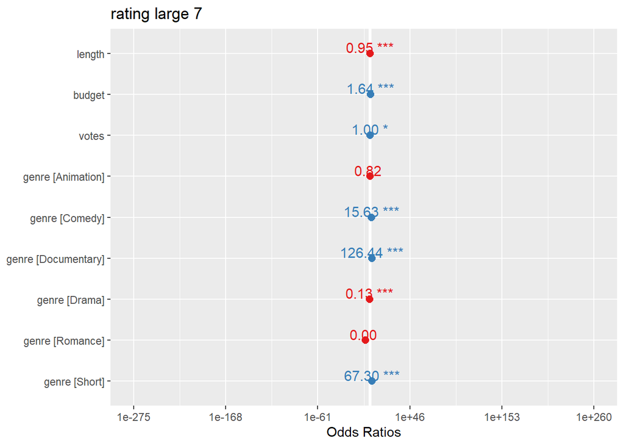

```r
plot_model(model1,show.values=TRUE)
```

# 5 prediction

```
## Data were 'prettified'. Consider using `terms="length [all]"` to get smooth plots.
```

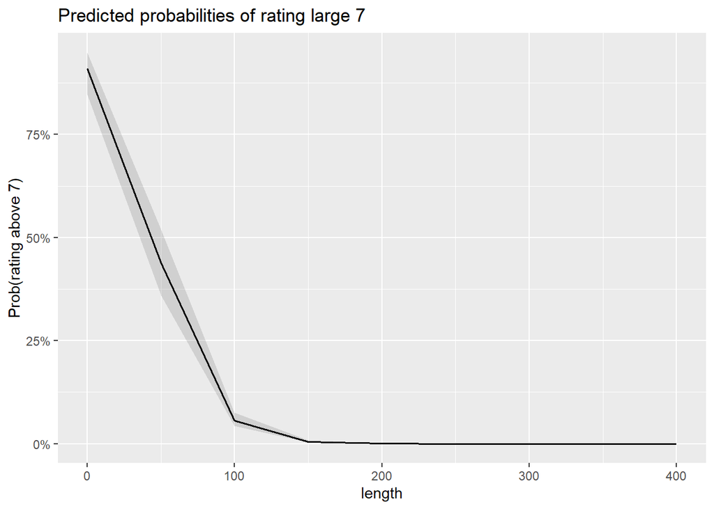

```r
plot_model(model1,type="pred",terms=c("length"),axis.title=c("length","Prob(rating above 7)"))
```

```
## Data were 'prettified'. Consider using `terms="votes [all]"` to get smooth plots.
```

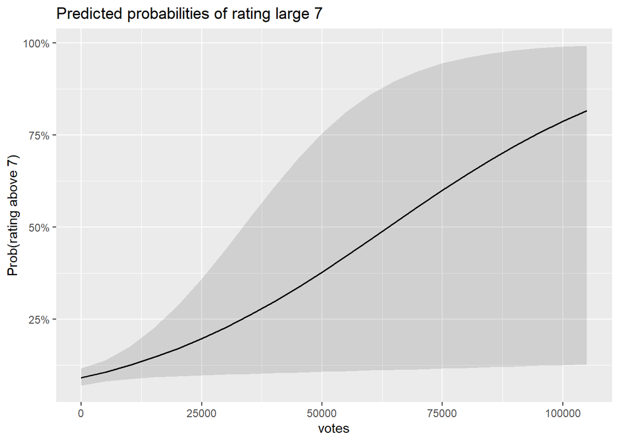

```r
plot_model(model1,type="pred",terms=c("votes"),axis.title=c("votes","Prob(rating above 7)"))
```

```
## Data were 'prettified'. Consider using `terms="budget [all]"` to get smooth plots.
```

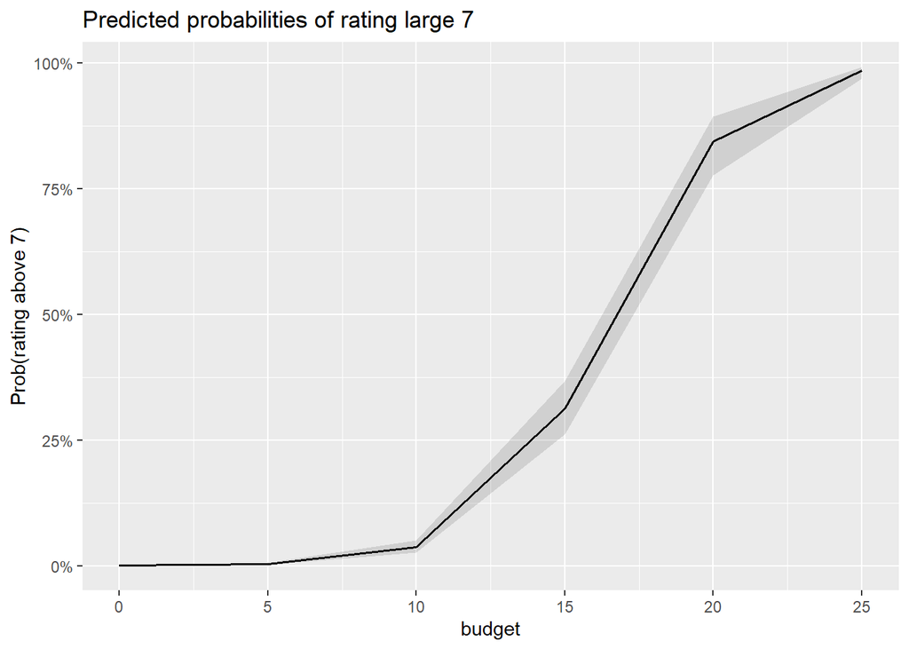

```r
plot_model(model1,type="pred",terms=c("budget"),axis.title=c("budget","Prob(rating above 7)"))
```

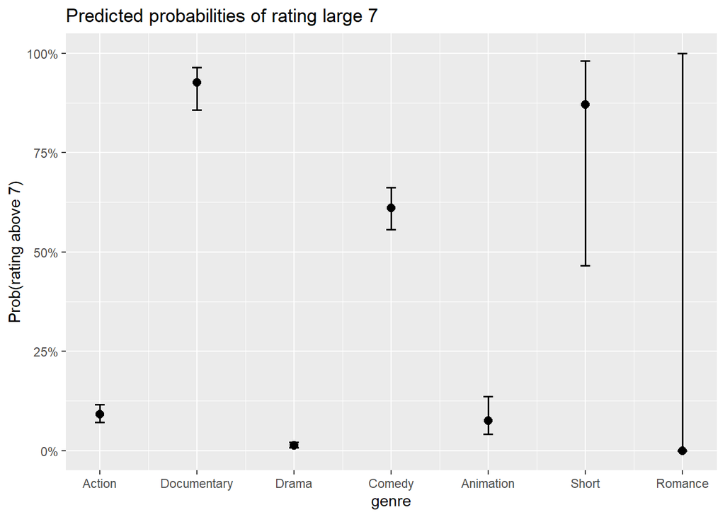

```r
plot_model(model1,type="pred",terms=c("genre"),axis.title=c("genre","Prob(rating above 7)"))
```

Model Comparison

[figure not shown]

```r
film_p <- data.frame(film = film,
                     logit = fitted(model1),
                     probit = fitted(model2),
                     cloglog = fitted(model3))
ggplot(film_p, aes(y = film$rating.large7, x = film$rating.large7)) +
geom_point() + xlab("Votes") + ylab("Rating") +
geom_line(aes(x = film$rating, y = logit, colour = "Logit")) +
geom_line(aes(x = film$rating, y = probit, colour = "Probit")) +
geom_line(aes(x = film$rating, y = cloglog, colour = "C log-log")) +
guides(colour = guide_legend("Method"))
```

ROC

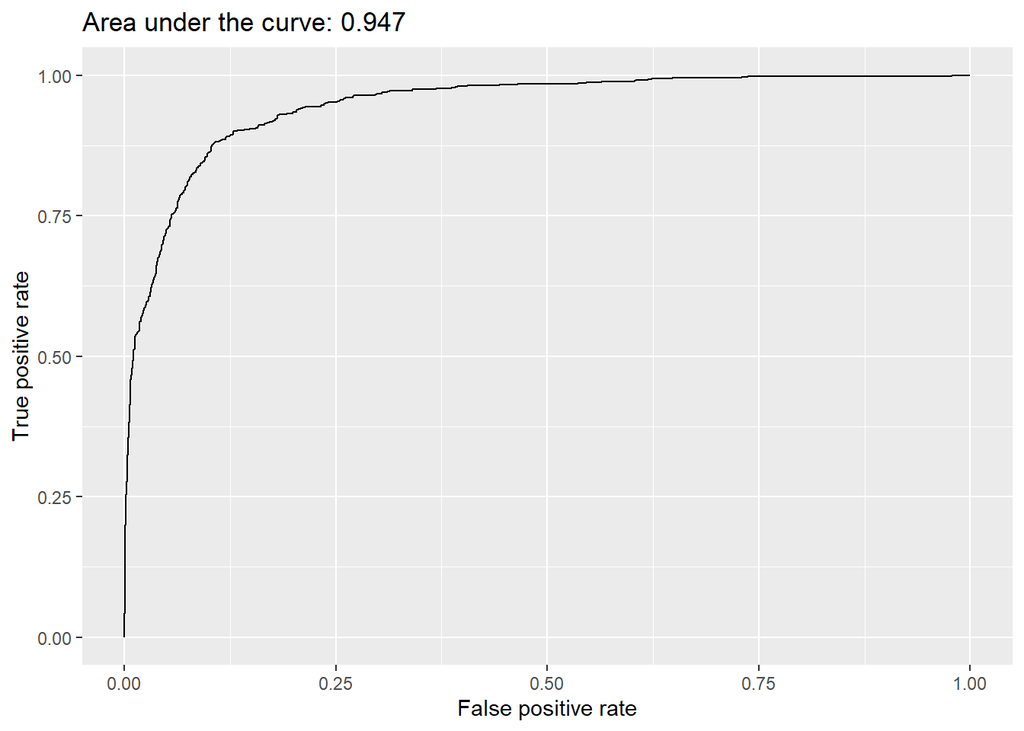

```r
film$Prid <- predict(model1, film, type="response")
score <- prediction(film$Prid,film$rating.large7)
perf <- performance(score,"tpr","fpr")
auc <- performance(score,"auc")
perfd <- data.frame(x= perf@x.values[1][[1]], y=perf@y.values[1][[1]])
p4<- ggplot(perfd, aes(x= x, y=y)) + geom_line() +
xlab("False positive rate") + ylab("True positive rate") +
ggtitle(paste("Area under the curve:", round(auc@y.values[[1]], 3)))
p4
```

AOC = 0.947 indicated that model 1 is very good at predicting the films rating greater than 7 given all predictor variables.